# R & RStudio Setup

### Verify R is installed

After installation, open a terminal (macOS/Linux) or the **R** application (Windows) and type:

```r
R.version.string
```

You should see something like `"R version 4.4.x (2024-xx-xx)"`.

2

Install RStudio Desktop

posit.co/download/rstudio-desktop · ~600 MB · 5 minutes

1. Go to **https://posit.co/download/rstudio-desktop/**
2. The page should auto-detect your OS. Click **Download RStudio Desktop** (the free version)
3. Run the installer and accept the defaults

🪟 Windows

🍎 macOS

🐧 Linux

Windows

Run the `.exe` installer. RStudio will locate your R installation automatically. Launch **RStudio** from the Start menu — *not* the **R** application icon.

macOS

Open the `.dmg`, drag **RStudio** to your Applications folder. On first launch, macOS may ask you to confirm — click **Open**. If a security dialog appears, go to **System Settings → Privacy & Security** and click **Open Anyway**.

Linux (Ubuntu/Debian)

Download the `.deb` installer from the Posit website and install it:

sudo dpkg -i rstudio-20xx.xx.x-xxx-amd64.deb  
sudo apt-get install -f # fix any missing dependencies

**✅ Confirm RStudio launched correctly**

When RStudio opens, you should see the **Console** pane (usually bottom-left) showing a message like `R version 4.4.x ... Type 'q()' to quit R.` If you see an error about R not being found, R may not be on your PATH — reinstall R and reopen RStudio.

3

Tour of the Four Panes

Know where everything lives before you start

RStudio divides its window into four panes. If you only see one or two, go to **View → Panes → Show All Panes** (`Ctrl`+`Shift`+`0` on Windows/Linux, `⌘`+`Shift`+`0` on macOS).

[output not shown]

[output not shown]

[output not shown]

[output not shown]

[output not shown]

[output not shown]

[output not shown]

[output not shown]

| Pane | What it does | Key shortcut to focus |
| --- | --- | --- |
| **Source** | Write and save scripts; send code to Console | `Ctrl`/`⌘`+`1` |
| **Console** | Run commands immediately; see output | `Ctrl`/`⌘`+`2` |
| **Environment** | See all objects currently in memory | `Ctrl`/`⌘`+`8` |
| **Files/Plots/Help** | Browse files, view plots, read documentation | `Ctrl`/`⌘`+`9` |

**✅ Resize panes freely** Drag any divider between panes to adjust the layout. You can also zoom a single pane to full-screen with `Ctrl`+`Shift`+`1` (Source) or `Ctrl`+`Shift`+`2` (Console).

4

Configure Global Options

Tools → Global Options

A few settings will save you hours of debugging. Go to **Tools → Global Options** and make these changes:

### General → Basic

- **Restore .RData into workspace at startup** → ☐ **Unchecked**
- **Save workspace to .RData on exit** → **Never**

**📌 Why these settings matter**

RStudio’s default is to save everything in memory to a hidden `.RData` file when you quit, then reload it next session. This sounds convenient but causes hard-to-find bugs: objects from a previous analysis silently persist and contaminate new analyses. Disabling this forces every script to be self-contained — the gold standard for reproducible science.

### Code → Editing

- **Use native pipe operator `|>` (requires R ≥ 4.1)** → ☑ Checked (optional but modern)
- **Auto-indent code after paste** → ☑ Checked
- **Insert matching parens/quotes** → ☑ Checked

### Appearance

Choose a theme and font size that you are comfortable reading for hours. Popular choices:

- **Themes:** Cobalt, Dracula, Monokai (dark); Chrome (light)
- **Editor font:** Source Code Pro or Fira Code
- **Font size:** 13–14pt for most screens

Click **Apply → OK** when done.

5

Create an RStudio Project

Every analysis should live in a Project — it sets the working directory automatically

RStudio Projects keep your scripts, data, and outputs together and set the **working directory** to the project folder automatically — no more `setwd("/Users/my/deeply/nested/path")`.

1. Go to **File → New Project**
2. Choose **New Directory → New Project**
3. Name it something like `EA030` and choose where to save it
4. Click **Create Project**

You will see a `.Rproj` file appear in the Files pane. Double-clicking it from Finder/Explorer reopens the project with all your files.

**✅ One project per class or analysis**

For EA030, create a single project and organise it with subfolders: `data/`, `scripts/`, `output/`, `reports/`. Reference files with relative paths like `read.csv("data/stream_data.csv")` — they will work on any machine with the same folder structure.

6

Write and Run Your First Script

File → New File → R Script

### Create a new script

Go to **File → New File → R Script** (or press `Ctrl`/`⌘`+`Shift`+`N`). A blank Source pane opens. Save it immediately as `setup_test.R` with `Ctrl`/`⌘`+`S`.

### Run the code below

Type (or paste) the following into your script. Select all with `Ctrl`/`⌘`+`A`, then run with `Ctrl`/`⌘`+`Enter`:

```r
# ── Basic arithmetic ──────────────────────────────────────────────
x <- c(2, 4, 6, 8, 10)         # create a numeric vector
mean(x)                          # mean
```

```
## [1] 6
```

```r
sd(x)                            # standard deviation
```

```
## [1] 3.162278
```

```r
summary(x)                       # five-number summary
```

```
##    Min. 1st Qu.  Median    Mean 3rd Qu.    Max.
##       2       4       6       6       8      10
```

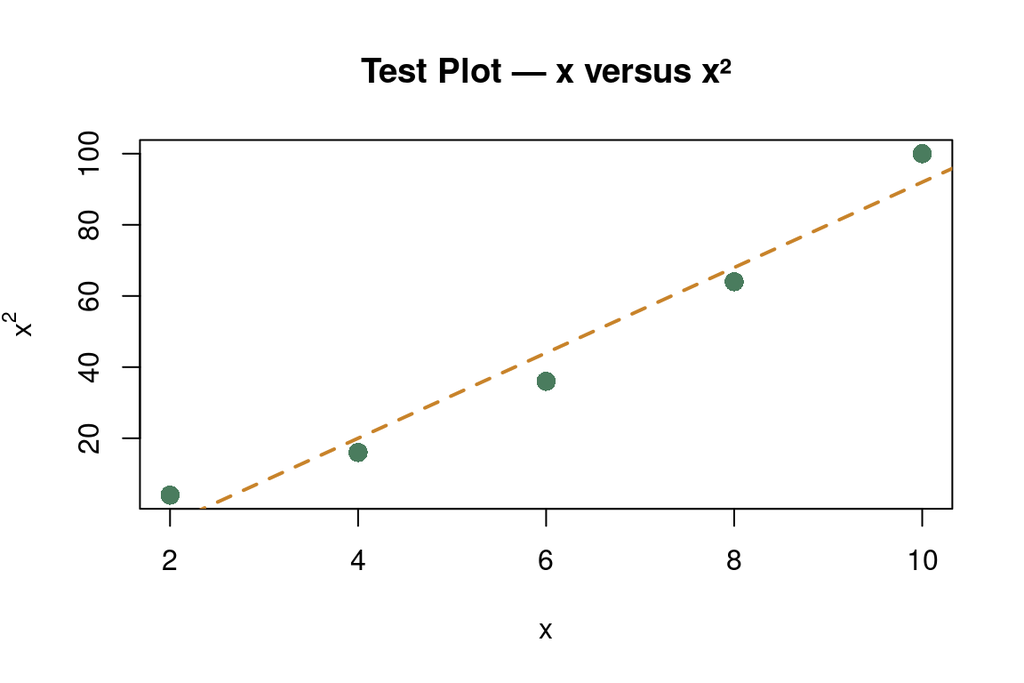

```r
# ── A simple plot ─────────────────────────────────────────────────
plot(x, x^2,
     main = "Test Plot — x versus x²",
     xlab = "x",
     ylab = expression(x^2),
     col  = "#4a7c5e",
     pch  = 16,
     cex  = 1.5)
abline(lm(x^2 ~ x), col = "#c8832a", lwd = 2, lty = 2)
```

The plot should appear in the **Plots** pane (pane 4). Use the left/right arrows at the top of the Plots pane to navigate plot history.

**✅ What success looks like**

Console shows the numeric output from `mean()`, `sd()`, and `summary()`. The Plots pane shows a scatter of five points with a dashed orange trend line. If you see a red error message instead, check the troubleshooting section at the end of this guide.